# Part 1: NEON phenology data exploration and visualization

*NOTE: before saving changes, make a copy of this file for yourself*

This is the first of a three part series for creating ecological forecasts of vegetation phenology, using Green Chromatic Coordinate from phenocams as our indicator. The first part downloads and explores data, the second part uses climate data to predict daily values of GCC, and the third part aggregates data to annual metrics to predict timing of spring green-up. This series was co-created with undergraduate student researchers at Cal Poly Humboldt and University of New Mexico Gallup.

Topics covered in part 1 include:

- introduction to `tidyverse`
- data visualization with `ggplot` and different geoms
- downloading neon summary weather data
- joining data frames

## Introduction to NEON data and this tutorial

This tutorial was created for undergraduate students who are new to coding in R and working with NEON data. It expands on steps to start coding from the [Ecological Forecast Challenge phenology theme](https://projects.ecoforecast.org/neon4cast-ci/targets.html). In addition to using a dataframe from the Ecological Forecasting Challenge, we download and use data from:

- [National Ecological Observatory Network](https://www.neonscience.org/data-samples), via the [`neonUtilities` package](https://www.neonscience.org/neonutilities)
- [PhenoCam network](https://phenocam.nau.edu/webcam/), via the [`phenocam` package](https://bluegreen-labs.github.io/phenocamr/)

In the Google Colab or Rmd file, you will see emojis to indicate a prompt to either stop and think and answer a question (🧠✍️) or to change a line of code and rerun it (💻). The goal is to help think through the steps and consider what the output means.

## Getting Started

When working in R, we first load in packages, which contain functions, data, and documentation that go beyond basic R. For this tutorial, we will use `tidyverse` which is a collection of packages that are useful for data organization, analysis, and visualization. When you run the following code you will see output of which packages are loaded. It’s important to do this step before doing anything else, because otherwise you could get an error trying to run functions from these packages.

Learn more about [tidyverse](https://www.tidyverse.org/learn/)!

**Notes about formatting:**

- this file is made up of code and markdown cells. Markdown cells contain text, and code cells contain code that you can run by pressing `ctrl+enter` or by clicking the ‘run’ button to the left
- comments are lines inside code chunks that are used to make notes, but do not run code. They start with a `#`

```r
# install if needed
if (!require(tidyverse, quietly = TRUE)){install.packages("tidyverse")}
# load in package
library(tidyverse)
```

## Load in and preview phenology data

In example below the following steps are taken

1. load in data
2. preview the data frame with `head()` and `dim()`
3. run summary to see the type of data and the values
4. filter by site (see list of sites and their IDs at the table at the end of this [link](https://projects.ecoforecast.org/neon4cast-ci/targets.html))

**Description of data**:

- `duration` is the time-step of the variable where PT30M is a 30-minute mean, P1D is a daily mean, and P1W is a weekly total.
- The `forecast horizon` is the number of days-ahead that we want you to forecast.
- The `latency` is the time between data collection and data availability in the target file
- `variable` is what is being observed
  - **gcc_90** - Green chromatic coordinate is the ratio of the green digital number to the sum of the red, green, blue digital numbers from a digital camera. Horizon: 30 days Latency: ~ 2 days
  - **rcc_90** - Red chromatic coordinate is the ratio of the Red digital number to the sum of the red, green, blue digital numbers from a digital camera. Horizon: 30 days Latency: ~ 2 days
- `site_id` is the code for the location. See all locations where phenology data is available ([see table](https://projects.ecoforecast.org/neon4cast-ci/targets.html) where phenology is marked 1)
- `observation` is the value for the variable being observed
- `datetime` is the date, and if measure less than a day, the time

```r
#set download url
url <- "https://sdsc.osn.xsede.org/bio230014-bucket01/challenges/targets/project_id=neon4cast/duration=P1D/phenology-targets.csv.gz"

# get data frame from website
phenology_targets <- read_csv(url, show_col_types = FALSE)

# preview - head shows the first six rows
head(phenology_targets)
```

```
## # A tibble: 6 × 6
##   project_id site_id datetime            duration variable observation
##   <chr>      <chr>   <dttm>              <chr>    <chr>          <dbl>
## 1 neon4cast  ABBY    2016-01-29 00:00:00 P1D      gcc_90            NA
## 2 neon4cast  ABBY    2016-01-30 00:00:00 P1D      gcc_90            NA
## 3 neon4cast  ABBY    2016-01-31 00:00:00 P1D      gcc_90            NA
## 4 neon4cast  ABBY    2016-02-01 00:00:00 P1D      gcc_90            NA
## 5 neon4cast  ABBY    2016-02-02 00:00:00 P1D      gcc_90            NA
## 6 neon4cast  ABBY    2016-02-03 00:00:00 P1D      gcc_90            NA
```

```r
# dim shows us how many columns and how many rows
dim(phenology_targets)
```

```
## [1] 359832      6
```

### Filter to selected site

Below, we filter the larger dataframe `phenology_targets` to a smaller one that only contains our site of interest.

In this example, I use SJER because I am interested in oak woodlands in California, but feel free to change the code to a different site to see the output. (see list of sites and their IDs at the table at the end of this [link](https://projects.ecoforecast.org/neon4cast-ci/targets.html))

The line used to filter contains two new parts:

- a pipe, `%>%`, which takes the dataframe before it and inserts it into the function that follows it, outputting the new dataframe. This can be used to combine multiple steps, but here we only have 1 step
- the `filter()` function, from the [`dplyr`](https://dplyr.tidyverse.org/reference/filter.html) package in tidyverse. This function uses a conditional statement applied to a column in your dataframe, and keeps all rows that match that condition. In this case, it will filter all rows that have ‘SJER’ in the column `site_id`

```r
# select your site
my_site = "SJER"

# filter by site id
site_targets <- phenology_targets %>% filter(site_id==my_site)

# preview the first six rows
head(site_targets)
```

```
## # A tibble: 6 × 6
##   project_id site_id datetime            duration variable observation
##   <chr>      <chr>   <dttm>              <chr>    <chr>          <dbl>
## 1 neon4cast  SJER    2016-01-29 00:00:00 P1D      gcc_90            NA
## 2 neon4cast  SJER    2016-01-30 00:00:00 P1D      gcc_90            NA
## 3 neon4cast  SJER    2016-01-31 00:00:00 P1D      gcc_90            NA
## 4 neon4cast  SJER    2016-02-01 00:00:00 P1D      gcc_90            NA
## 5 neon4cast  SJER    2016-02-02 00:00:00 P1D      gcc_90            NA
## 6 neon4cast  SJER    2016-02-03 00:00:00 P1D      gcc_90            NA
```

```r
dim(site_targets)
```

```
## [1] 7656    6
```

```r
# get a summary of the data
summary(site_targets)
```

```
##      project_id        site_id        datetime
##  Length   :7656   Length   :7656   Min.   :2016-01-29 00:00:00
##  N.unique :   1   N.unique :   1   1st Qu.:2018-09-11 18:00:00
##  N.blank  :   0   N.blank  :   0   Median :2021-04-25 12:00:00
##  Min.nchar:   9   Min.nchar:   4   Mean   :2021-04-25 12:00:00
##  Max.nchar:   9   Max.nchar:   4   3rd Qu.:2023-12-08 06:00:00
##                                    Max.   :2026-07-22 00:00:00
##
##       duration         variable     observation
##  Length   :7656   Length   :7656   Min.   :0.3227
##  N.unique :   1   N.unique :   2   1st Qu.:0.3736
##  N.blank  :   0   N.blank  :   0   Median :0.3792
##  Min.nchar:   3   Min.nchar:   6   Mean   :0.3834
##  Max.nchar:   3   Max.nchar:   6   3rd Qu.:0.3896
##                                    Max.   :0.5859
##                                    NAs    :2032
```

In the output, you should see only the site you filtered in the `site_id` column.

🧠✍️ Based on the output, consider the following questions:

- What is the time range for these observations?
- How many missing values (NA) does it contain?
- What is the duration?

## Visualizing data

We are going to use `ggplot2`, which is another tidyverse package, to visualize our data.

You can read more, and see examples of chart types, [here](https://ggplot2.tidyverse.org/)

The pattern to follow is:

`ggplot(dataframe, aes(x, y)) + geom_charttype()`

See the first example of a time series of both gcc_90 and rcc_90 below:

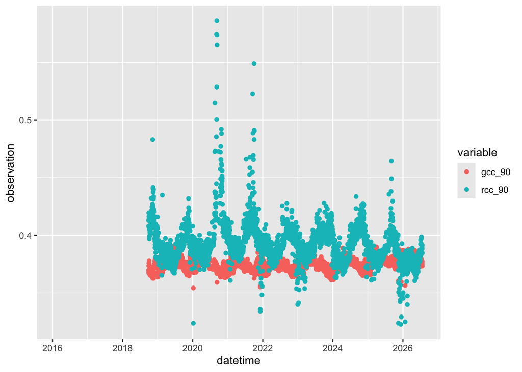

```r
# plot time series
ggplot(site_targets, aes(x=datetime, y=observation, col=variable)) +
  geom_point()
```

🧠✍️ Based on the output, consider the following questions:

- What patterns do you notice?
- What time of year do we see peak gcc90 and rcc90?
- If you were to go back and re-run this for a different site, would you expect the same patterns?

### Working with geoms to change how your data is displayed

In the above plot, we created a time series scatter plot using `geom_point()`. Geoms determine how your data is displayed.

💻 Try rerunning the same code as above but with `geom_line()`.

Geoms can also be layered. You can use both point and line to create a time series.

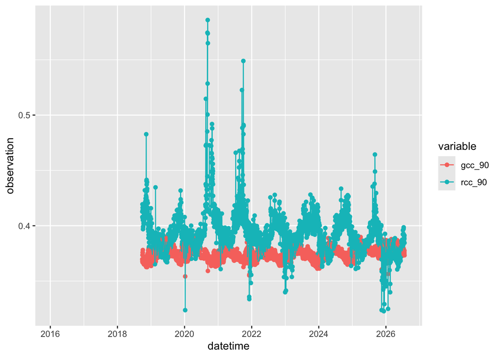

```r
# plot a time series with line
ggplot(site_targets, aes(x=datetime, y=observation, col=variable)) +
  geom_point() +
  geom_line()
```

### Visualizing groups: faceting

In the plot above, two groups are shown as different colors, with considerable overlap of points. To more clearly compare these two groups, we can use `facet_grid()`, which creates panels separated by a discrete variable.

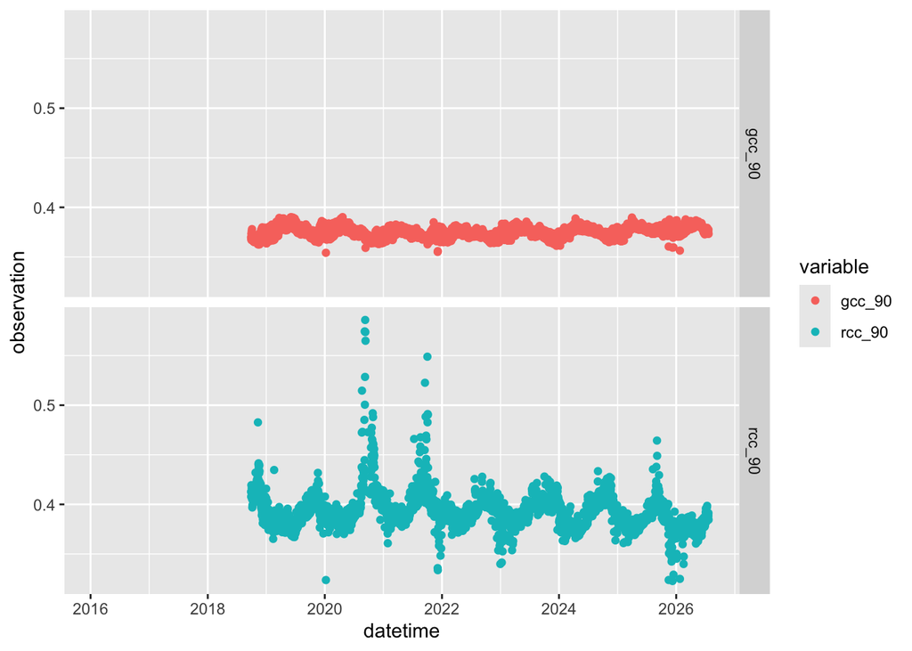

```r
# look at red and green separately - we can do this using facet_grid
ggplot(site_targets, aes(x=datetime, y=observation, col=variable)) +
  geom_point() +
  facet_grid("variable")
```

### Visualizing groups: boxplots

Using geoms, there are several ways to display our data to better visualize the difference between two variables, in this case `gcc_90` and `rcc_90`.

In the below example, we can compare `gcc_90` and `rcc_90` as boxplots.

🧠✍️ Run the code below and think about: - How does visualizing data as a time series and as a boxplot affect the information we gain from the visualization

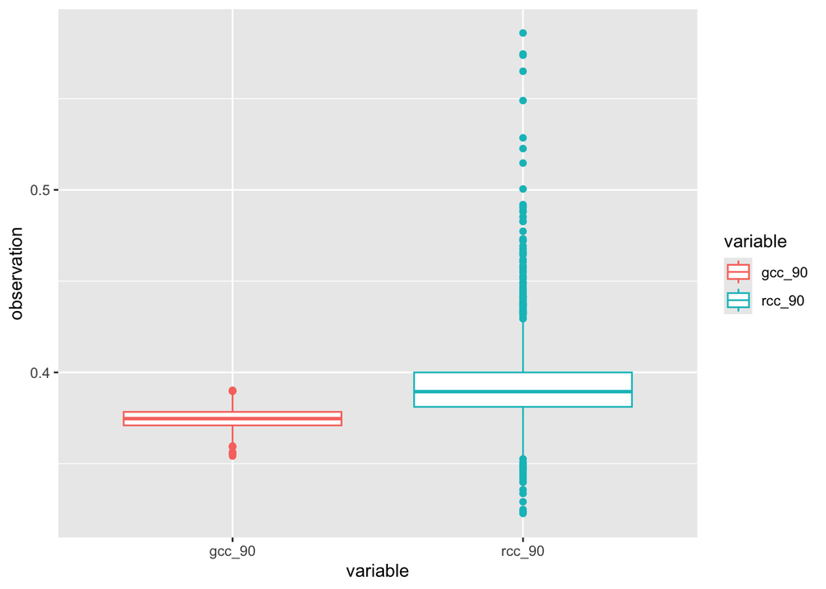

```r
# plot a boxplot
ggplot(site_targets, aes(x=variable, y=observation, col=variable)) +
  geom_boxplot()
```

### Creating time series with different x-axis

The dataframe has one column for time, `datetime`, but what if we want to visualize at different temporal resolutions? We can create new columns for month, year, and day of year (doy), then use `group_by()` and `summarize()` to create new time series visualizations and gain new insight about our data.

The new columns for temporal resolution are created using the [`lubridate`](https://lubridate.tidyverse.org/) package, which has functions for `month()`, `year()`, and `yday()` that take a date as input and extract the timestep.

```r
# plot time series of annual values - x-axis as month or day

# will need to get new columns that are month and day of year
site_targets$month = month(site_targets$datetime)
site_targets$year = year(site_targets$datetime)
site_targets$doy =yday(site_targets$datetime)

# using these columns we can group and summarize
sites_doy = site_targets %>%
  group_by(doy, variable) %>%
  summarize(mean_obs = mean(observation, na.rm=T))
```

```
## `summarise()` has regrouped the output.
## ℹ Summaries were computed grouped by doy and variable.
## ℹ Output is grouped by doy.
## ℹ Use `summarise(.groups = "drop_last")` to silence this message.
## ℹ Use `summarise(.by = c(doy, variable))` for per-operation grouping
##   (`?dplyr::dplyr_by`) instead.
```

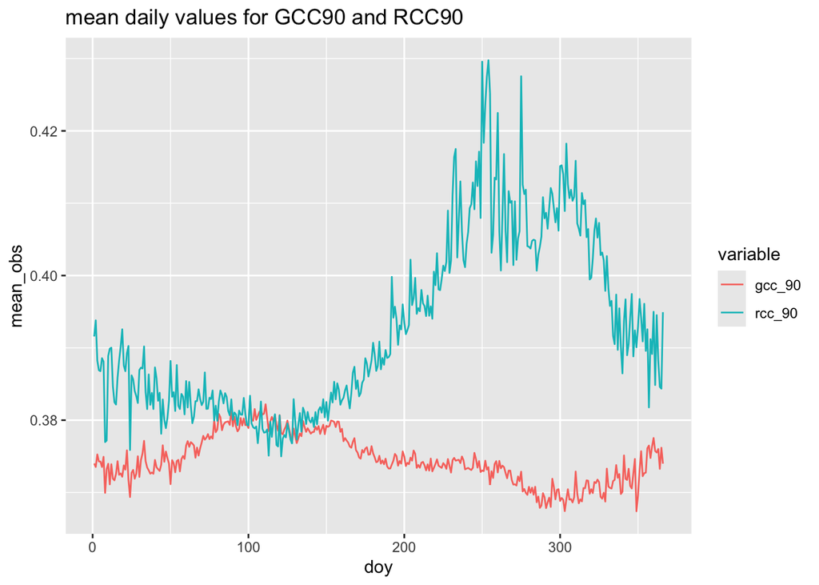

```r
ggplot(sites_doy, aes(x=doy, y=mean_obs, col=variable))+
  geom_line() +
  ggtitle("mean daily values for GCC90 and RCC90")
```

Looking at daily averages within a year can give us insight to seasonal patterns.

💻 Try changing from `doy` to `month` in the above code (lines 9-15 in Google Colab, or 210-217 in R)

## Loading climate data

We are going to load more data using the `neonUtilities` R package, using examples from [this tutorial](https://www.neonscience.org/resources/learning-hub/tutorials/neondatastackr).

First we are installing and loading the package.

```r
# run this first to install
#install.packages("neonUtilities")

# load package

library(neonUtilities)
```

### Load by product

We are going to use the summary weather statistics (DP4.00001.001) data product. It includes daily temperatures, averaged via an algorithm that handles the quality flags etc along the way. It’s currently only available for core sites. [Read more about summary weather statistics here.](https://data.neonscience.org/data-products/DP4.00001.001)

The information needed to load the product, with the function `loadByProduct()` include: - data ID (dpID): for our purpose this is DP4.00001.001. See a full list of data products [here](https://data.neonscience.org/data-products/explore) - site: we have already created the variable `my_site` - optionally, startdate and enddate. In the code below, objects for `start` and `end` are created based on availability from our site’s GCC_90 dataframe.

💻 Note: as of June 2026, NEON requires an API token to download data.Set up your API token [here](https://www.neonscience.org/resources/learning-hub/tutorials/api-token-setup). This should be a string that you save on your machine, then include this additional parameter to the `loadByProduct()` function: `token="yourAPIkey"`

In this case I have saved my NEON API key in my `.Renviron` file, and then I read it in with `Sys.getenv("NEON_API_KEY")`. See an example of doing this [here](https://laurenilano.com/posts/api-keys/).

```r
# this may take a few minutes to download data!

# set data ID
data_id = "DP4.00001.001"

# get the start and end dates for the SJER site
# the functions below select the first and last date entry in the datetime column, then format to Year-month
start = format(site_targets$datetime[1], "%Y-%m")
end = format(site_targets$datetime[nrow(site_targets)], "%Y-%m")


# download the summary weather statistics files - for site SJER - check your console, this may take a minute

summary_weather <- loadByProduct(dpID=c(data_id),
                          site=c(my_site),
                          startdate=start,
                          enddate=end,
                          check.size=F,
                          progress=F,
                          token=Sys.getenv("NEON_API_KEY")
                          )
```

```
## Provisional data were excluded from available files list. To download provisional data, use input parameter include.provisional=TRUE.
```

```r
# the format of this download is a list that contains metadata and data frames

# lets preview the data we loaded
str(summary_weather) # this function displays the structure of an object - it should output for each item in the list, with labels - see which are data frames
```

```
## List of 17
##  $ citation_00001_RELEASE-2026: chr "@misc{https://doi.org/10.48443/w4cw-j689,\n  doi = {10.48443/W4CW-J689},\n  url = {https://data.neonscience.org"| __truncated__
##  $ issueLog_00001             :'data.frame': 8 obs. of  9 variables:
##   ..$ id              : int [1:8] 7158 15420 18114 58504 66512 98204 109004 110312
##   ..$ parentIssueID   : logi [1:8] NA NA NA NA NA NA ...
##   ..$ issueDate       : chr [1:8] "2019-02-19T00:00:00Z" "2020-06-10T00:00:00Z" "2021-01-14T00:00:00Z" "2022-06-20T00:00:00Z" ...
##   ..$ resolvedDate    : chr [1:8] "2019-02-19T00:00:00Z" "2020-06-10T00:00:00Z" "2021-12-31T00:00:00Z" "2022-06-20T00:00:00Z" ...
##   ..$ dateRangeStart  : chr [1:8] "2018-01-01T00:00:00Z" "2013-01-01T00:00:00Z" "2020-03-23T00:00:00Z" "2013-01-01T00:00:00Z" ...
##   ..$ dateRangeEnd    : chr [1:8] "2018-10-31T00:00:00Z" "2020-06-10T00:00:00Z" "2021-12-31T00:00:00Z" "2022-06-20T00:00:00Z" ...
##   ..$ locationAffected: chr [1:8] "All locations." "All" "ALL" "All" ...
##   ..$ issue           : chr [1:8] "Incorrect calibration information was applied to data for some sites and time periods." "All data were reprocessed with the most recent algorithms, quality control thresholds, and/or other metadata to"| __truncated__ "Safety measures to protect personnel during …
##   ..$ resolution      : chr [1:8] "Data reprocessed with correct calibration information." "Informational log only" "NEON reviewed data from all sites and time periods potentially impacted by COVID-19 safety precautions to ident"| __truncated__ "Data republished." ...
##  $ readme_00001               :'data.frame': 109 obs. of  1 variable:
##   ..$ V1: chr [1:109] "###################################\n" "########### Disclaimer ############\n" "This is the most recent readme publication based on all site-date combinations used during stackByTable.\nInfor"| __truncated__ "##################################\n" ...
##  $ sensor_positions_00001     :'data.frame': 12 obs. of  26 variables:
##   ..$ domainID                        : chr [1:12] "D17" "D17" "D17" "D17" ...
##   ..$ siteID                          : chr [1:12] "SJER" "SJER" "SJER" "SJER" ...
##   ..$ HOR.VER                         : chr [1:12] "000.010" "000.020" "000.030" "000.030" ...
##   ..$ sensorLocationID                : chr [1:12] "CFGLOC113231" "CFGLOC113235" "CFGLOC113239" "CFGLOC113239" ...
##   ..$ sensorLocationDescription       : chr [1:12] "San Joaquin 2D Wind L1" "San Joaquin 2D Wind L2" "San Joaquin 2D Wind L3" "San Joaquin 2D Wind L3" ...
##   ..$ positionStartDateTime           : POSIXct[1:12], format: "2010-01-01" "2010-01-01" ...
##   ..$ positionEndDateTime             : POSIXct[1:12], format: NA NA ...
##   ..$ referenceLocationID             : chr [1:12] "TOWER113088" "TOWER113088" "TOWER113088" "TOWER113088" ...
##   ..$ referenceLocationIDDescription  : chr [1:12] "San Joaquin Tower" "San Joaquin Tower" "San Joaquin Tower" "San Joaquin Tower" ...
##   ..$ referenceLocationIDStartDateTime: POSIXct[1:12], format: "2010-01-01" "2010-01-01" ...
##   ..$ referenceLocationIDEndDateTime  : POSIXct[1:12], format: NA NA ...
##   ..$ xOffset                         : num [1:12] -4.24 -4.24 -4.23 -4.23 -4.23 -0.03 -4.24 -4.24 -0.61 0.86 ...
##   ..$ yOffset                         : num [1:12] 2.36 2.36 2.36 2.36 2.36 1.71 2.36 2.36 5.16 2.48 ...
##   ..$ zOffset                         : num [1:12] 0.3 1.45 5.46 5.46 5.46 ...
##   ..$ pitch                           : num [1:12] 0 0 0 0 0 0 0 0 0 0 ...
##   ..$ roll                            : num [1:12] 0 0 0 0 0 0 0 0 0 0 ...
##   ..$ azimuth                         : num [1:12] 90 90 90 270 90 0 90 90 0 0 ...
##   ..$ locationReferenceLatitude       : num [1:12] 37.1 37.1 37.1 37.1 37.1 ...
##   ..$ locationReferenceLongitude      : num [1:12] -120 -120 -120 -120 -120 ...
##   ..$ locationReferenceElevation      : num [1:12] 400 400 400 400 400 ...
##   ..$ eastOffset                      : num [1:12] 4.24 4.24 4.23 4.23 4.23 0.03 4.24 4.24 0.61 -0.86 ...
##   ..$ northOffset                     : num [1:12] -2.36 -2.36 -2.36 -2.36 -2.36 -1.71 -2.36 -2.36 -5.16 -2.48 ...
##   ..$ xAzimuth                        : num [1:12] 270 270 270 270 270 270 270 270 270 270 ...
##   ..$ yAzimuth                        : num [1:12] 180 180 180 180 180 180 180 180 180 180 ...
##   ..$ publicationDate                 : chr [1:12] "20260108T180926Z" "20260108T180926Z" "20260108T180926Z" "20260108T180926Z" ...
```

[output cut: 204 more lines]

```
##  $ wss_yearly_wind            :'data.frame': 1 obs. of  14 variables:
##   ..$ domainID             : chr "D17"
##   ..$ siteID               : chr "SJER"
##   ..$ horizontalPosition   : chr "000"
##   ..$ verticalPosition     : chr "010"
##   ..$ year                 : int 2019
##   ..$ wssWindSpeedMean     : num NA
##   ..$ wssWindSpeedMinimum  : num NA
##   ..$ wssWindSpeedMaximum  : num NA
##   ..$ wssWindSpeedVariance : num NA
##   ..$ wssWindSpeedStdErMean: num NA
##   ..$ wssWindSpeedNumPts   : num 3e+07
##   ..$ windSpeedQF          : int 1
##   ..$ publicationDate      : chr "20260108T180029Z"
##   ..$ release              : chr "RELEASE-2026"
```

The output of the `str()` function lists the names of the dataframe, the dimension of each dataframe, and the column names and data types. It is a long list!

To simplify for our purposes, we are going to only use the daily temperature. Below we start a new data frame that takes the daily temperature from the larger list.

```r
# we are looking for daily temperatures, wss_daily_temp

# let's create a data frame for the daily observations and preview it

neon_daily_temp = summary_weather$wss_daily_temp

# now we have a data frame instead of a list, lets preview that - there are several ways to do this:

# print first 6 rows
head(neon_daily_temp)
```

```
##   domainID siteID horizontalPosition verticalPosition       date
## 1      D17   SJER                000              060 2018-10-01
## 2      D17   SJER                000              060 2018-10-02
## 3      D17   SJER                000              060 2018-10-03
## 4      D17   SJER                000              060 2018-10-04
## 5      D17   SJER                000              060 2018-10-05
## 6      D17   SJER                000              060 2018-10-06
##   wssTempTripleMean wssTempTripleMinimum wssTempTripleMaximum
## 1           22.7745              19.1301              27.9541
## 2           23.7680              17.2116              27.6371
## 3           21.4341              17.3905              26.8699
## 4           18.4020              15.4876              22.0929
## 5           17.9040              14.9167              22.3902
## 6           18.7083              14.7952              23.2371
##   wssTempTripleVariance wssTempTripleStdErMean wssTempTripleNumPts tempTripleQF
## 1                5.4576                 0.0087               71980            0
## 2                5.8955                 0.0083               86400            0
## 3                5.6448                 0.0081               86400            0
## 4                3.4277                 0.0063               86400            0
## 5                4.3737                 0.0071               86400            0
## 6                5.0934                 0.0077               86400            0
##    publicationDate      release
## 1 20260108T174046Z RELEASE-2026
## 2 20260108T174046Z RELEASE-2026
## 3 20260108T174046Z RELEASE-2026
## 4 20260108T174046Z RELEASE-2026
## 5 20260108T174046Z RELEASE-2026
## 6 20260108T174046Z RELEASE-2026
```

```r
# see column names
colnames(neon_daily_temp)
```

```
##  [1] "domainID"               "siteID"                 "horizontalPosition"
##  [4] "verticalPosition"       "date"                   "wssTempTripleMean"
##  [7] "wssTempTripleMinimum"   "wssTempTripleMaximum"   "wssTempTripleVariance"
## [10] "wssTempTripleStdErMean" "wssTempTripleNumPts"    "tempTripleQF"
## [13] "publicationDate"        "release"
```

### Explore temperature dataframe

From the preview, we can see our dataframe contains a few columns of interest:

- date
- wssTempTripleMean
- wssTempTripleMaximum
- wssTempTripleMinimum

We can select these columns are run `summary()` to get descriptive statistics.

```r
# summary statistics of columns we are interested in
neon_daily_temp %>%
  select(date, wssTempTripleMean, wssTempTripleMaximum, wssTempTripleMinimum)  %>%
  summary()
```

```
##       date            wssTempTripleMean wssTempTripleMaximum
##  Min.   :2018-09-06   Min.   : 1.706    Min.   : 5.018
##  1st Qu.:2020-05-20   1st Qu.:11.655    1st Qu.:15.454
##  Median :2022-02-01   Median :17.449    Median :22.875
##  Mean   :2022-02-01   Mean   :18.420    Mean   :23.387
##  3rd Qu.:2023-10-16   3rd Qu.:25.595    3rd Qu.:31.607
##  Max.   :2025-06-30   Max.   :36.777    Max.   :42.526
##                       NAs    :42        NAs    :42
##  wssTempTripleMinimum
##  Min.   :-1.163
##  1st Qu.: 8.435
##  Median :13.220
##  Mean   :14.542
##  3rd Qu.:20.999
##  Max.   :31.745
##  NAs    :42
```

Next we can plot daily values to see the entire time series. In this example, we are layering different geoms and changing the y variable to show the mean, minimum, and maximum temperature together on the same plot.

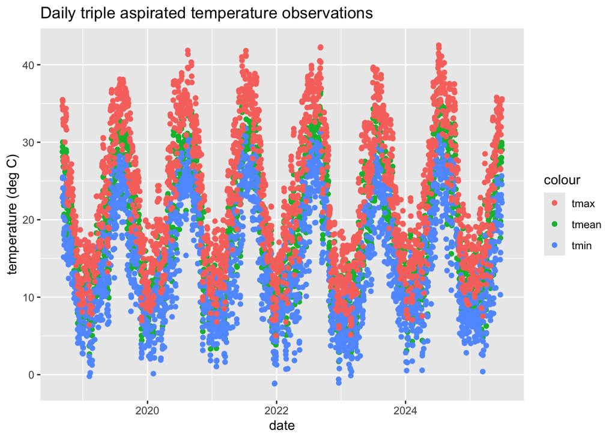

```r
# create a plot
ggplot(neon_daily_temp,
       aes(x=date, y=wssTempTripleMean, col="tmean")) +
  geom_point() +
  geom_point(aes(x=date, y=wssTempTripleMinimum, col="tmin")) +
  geom_point(aes(x=date, y=wssTempTripleMaximum, col="tmax")) +
  labs(title="Daily triple aspirated temperature observations",
        x="date",
        y="temperature (deg C)")
```

## Join GCC_90 data with temperature data

We are going to use the `join` function to put together two data frames - `site_targets` (which includes the gcc and rcc data), and `neon_daily_temp` (which is the daily temperature data we downloaded above). In order to use a join function, we need a column in each data frame with common keys and the same column name, in this case we will use `date` column.

The formula is:

`new_dataframe <- full_join(dataframe1, dataframe2, by='key')`

Read more about `join` functions [here](https://dplyr.tidyverse.org/reference/mutate-joins.html).

```r
# first need to make sure sites has date col
site_targets$date <- site_targets$datetime

# full join includes all columns from both data frames
neon_join <- full_join(site_targets, neon_daily_temp, by='date')

# preview data frame
head(neon_join)
```

```
## # A tibble: 6 × 23
##   project_id site_id datetime            duration variable observation month
##   <chr>      <chr>   <dttm>              <chr>    <chr>          <dbl> <dbl>
## 1 neon4cast  SJER    2016-01-29 00:00:00 P1D      gcc_90            NA     1
## 2 neon4cast  SJER    2016-01-30 00:00:00 P1D      gcc_90            NA     1
## 3 neon4cast  SJER    2016-01-31 00:00:00 P1D      gcc_90            NA     1
## 4 neon4cast  SJER    2016-02-01 00:00:00 P1D      gcc_90            NA     2
## 5 neon4cast  SJER    2016-02-02 00:00:00 P1D      gcc_90            NA     2
## 6 neon4cast  SJER    2016-02-03 00:00:00 P1D      gcc_90            NA     2
## # ℹ 16 more variables: year <dbl>, doy <dbl>, date <dttm>, domainID <chr>,
## #   siteID <chr>, horizontalPosition <chr>, verticalPosition <chr>,
## #   wssTempTripleMean <dbl>, wssTempTripleMinimum <dbl>,
## #   wssTempTripleMaximum <dbl>, wssTempTripleVariance <dbl>,
## #   wssTempTripleStdErMean <dbl>, wssTempTripleNumPts <dbl>,
## #   tempTripleQF <int>, publicationDate <chr>, release <chr>
```

Note the columns for our temperature statistics are all NA - this is because the gcc data starts in 2016 but the temperature data doesn’t start until 2018.

Next we can explore plots for any patterns.

I want to see a plot of both temperature and GCC. To do this, I am loading and using the library `patchwork`, which allows you to combine ggplot visualizations once they have been saved as objects. In the example below, I plot daily temperature on top of daily GCC.

[figure not shown]

```r
# get the package patchwork
#install.packages('patchwork')
library(patchwork)


# create temperature time series plot
temp_plot = neon_join %>%
  filter(year>2018) %>% # filter past the dates with NA
  ggplot(aes(y=wssTempTripleMean,x=date)) +
    geom_point(col="red") + geom_line() + # plot daily tmin
    theme_bw() + # makes background white
    ggtitle("minimum daily temperature") # add title

# create gcc90 time series plot
gcc90_plot = neon_join %>%
  filter(variable=="gcc_90") %>%
  filter (year>2018) %>% # filter past dates with NA
  ggplot(aes(y=observation, x=date)) +
    geom_point(col="lightgreen") + geom_line() + # plot daily gcc
    theme_bw() + # makes background white
    ggtitle("daily GCC 90") # add title

# display plots with temp on top of gcc90
temp_plot/gcc90_plot
```

🧠✍️ What patterns are you noticing? Does there look like there’s a relationship between temperature and greenness?

To further explore a relationship between two variables, we can create a scatter plot.

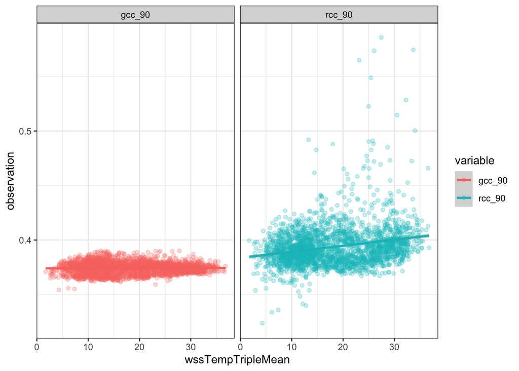

```r
ggplot(neon_join, aes(x=wssTempTripleMean, y=observation, col=variable)) + # plot daily tmin v. observation, colored and faceted by variable
  geom_point(alpha=0.25) + # alpha sets the opacity
  geom_smooth(method='lm') + # add a linear smoothing
  facet_grid(.~variable) + # facet by variable
  theme_bw() # makes background white
```

## Saving your data

This is an important step because we have loaded data to our working environment, but don’t have it saved to our computer. We can save `neon_daily_temp` so that we don’t need to repeat the process above of downloading and subsetting this dataframe.

The code below automatically creates a name for a CSV file, then saves your dataframe. Note that if working in Google Colab, you will need to download this to your desktop.

```r
# save dataframe to computer so don't have to download again

filename = paste(my_site, data_id, "NEON.csv", sep="_")

# once you save it you should be able to read it in again using the function read_csv()
write.csv(neon_daily_temp, filename)

# save the joined data too
write.csv(neon_join,"gcc_neon_join.csv", row.names = F)

# after you run this, see the file on the left hand side if working in google colab, be sure to download to computer
```

## Review Part 1

1. Installed and loaded libraries including `tidyverse`
2. Downloaded and explored daily phenology data from Ecological Forecasting challenged
3. Filtered data by site
4. Visualized data with `ggplot`, tried different geoms
5. Downloaded, subset, and explored temperature data from `neonUtilities` package
6. Joined phenology and temperature data to plot

# Extra step: Creating Presentation ready plots

So far we have used visualization for our own data exploration, but when including plots on a poster, it’s important to ‘clean’ up the plots to show everything clearly with contextual information.

Important things to consider include:

- color (does it clearly represent story, is it color-deficient friendly)
- line size
- dimensions of photo (to be printed on a 48x36in poster)
- text size
- clearly labeled axis (include units, legend)

See more about what makes a good data visualization [here](https://drive.google.com/file/d/1AcN8bVmAtWfQ_Zb-EqZs2FmK1RZ8mkOY/view).

Below is an example of improving the time series of temperature. First is the original plot from above, with tmin and tmax as variables. Key improvements that were made to create a ‘poster ready’ plot are shown, along with the updated plot.

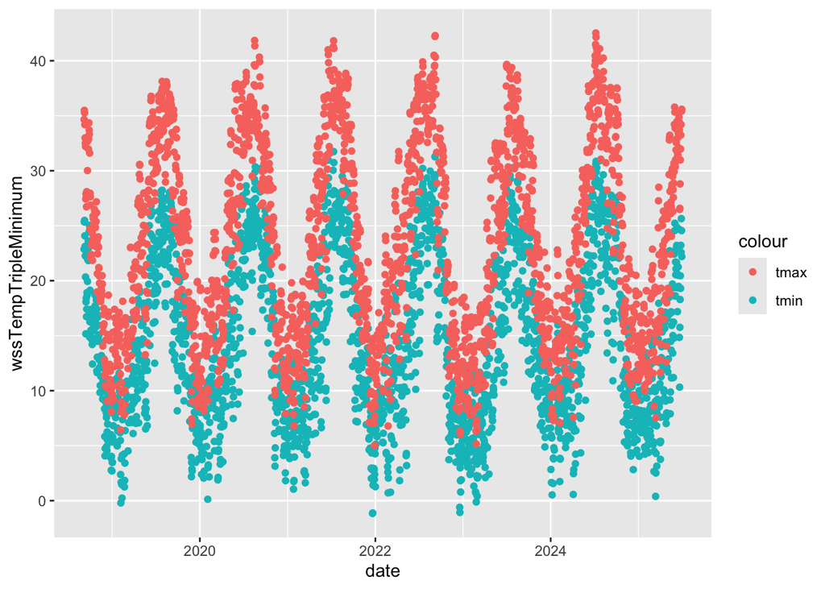

```r
ggplot(neon_daily_temp) +
  geom_point(aes(x = date, y = wssTempTripleMinimum, col = "tmin")) +
  geom_point(aes(x = date, y = wssTempTripleMaximum, col = "tmax"))
```

To update this plot, a number of changes to settings can be made using ggplot, often involving specific functions or parameters. This includes changing colors, adjusting the size of data, axis, and text, and the overall look. To see examples and learn more about the different options, see the [R Graphics Cookbook](https://r-graphics.org/index.html) or the [ggplot website](https://ggplot2.tidyverse.org/).

## Using generative AI as a tool

Along with using the ggplot website and book links to find how to change settings, we can use generative AI to update our plot. Here is an example for the temperature time series, using Claude.ai, and giving this prompt:

“I am creating a plot in R with ggplot for a poster that is 48x36 inches. I need the plot to have text that is large enough to read from 3 ft away, clear points and axis. Here is my starting code:

`ggplot(minute_daily_avg) + geom_point(aes(x=date, y=tmin, col="tmin")) + geom_point(aes(x=date, y=tmax, col="tmax"))`

Can you add a theme, make the colors red for tmax and blue for tmin, make the text larger, and clearly label axis that temperature is in degrees C?”

Here is the output:

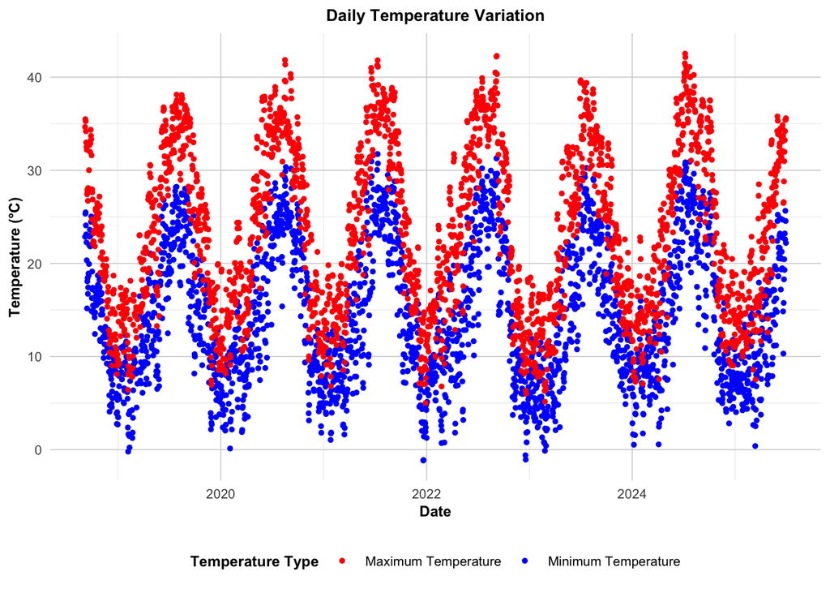

```r
# Create the plot and assign it to a variable
temperature_plot <- ggplot(neon_daily_temp) +
  geom_point(aes(x = date, y = wssTempTripleMinimum, col = "Minimum Temperature"), size = 1) +
  geom_point(aes(x = date, y = wssTempTripleMaximum, col = "Maximum Temperature"), size = 1) +
  scale_color_manual(values = c("Minimum Temperature" = "blue",
                                "Maximum Temperature" = "red"),
                     name = "Temperature Type") +
  labs(x = "Date",
       y = "Temperature (°C)",
       title = "Daily Temperature Variation") +
  theme_minimal() +
  theme(
    text = element_text(size = 8),
    axis.title = element_text(size = 9, face = "bold"),
    axis.text = element_text(size = 8),
    legend.text = element_text(size = 8),
    legend.title = element_text(size = 9, face = "bold"),
    plot.title = element_text(size = 10, face = "bold", hjust = 0.5),
    panel.grid.major = element_line(color = "gray80", linewidth = 0.25),
    panel.grid.minor = element_line(color = "gray90", linewidth = 0.15),
    legend.position = "bottom"
  )

temperature_plot
```

If using generative AI, it’s important to look through the output code to make sure you can understand what it is doing. In this case, it generated text to update the colors, labels, and parameters inside theme() to change size and look of the overall plot.

You can edit the above code to make it more specific to your plot - change the title and labels, or colors!

## Saving the plot

Be sure to save your plot by running the code below. If you are working in Google colab, you will also need to download it to your personal computer, or copy and paste.

```r
# Save the plot with ggsave
ggsave(filename = "temp_plot_4x6.png",
       plot = temperature_daily_plot,
       width = 6,
       height = 4,
       units = "in",
       dpi = 300)
```

# More resources to continue learning about NEON data and phenology

Other tutorials that may be of interest:

- [NDVI timeseries](https://www.neonscience.org/resources/learning-hub/tutorials/aop-gee-ndvi-timeseries)
- [Diel carbon fluxes](https://www.neonscience.org/resources/learning-hub/tutorials/eddy-diel-cycle#3-plotting-the-diel-cycle-of-co2-fluxes)
- [Relating reflectance indices](https://www.neonscience.org/resources/learning-hub/tutorials/flux-footprint-ndvi)
- [tutorial on working with eddy flux data](https://www.neonscience.org/resources/learning-hub/tutorials/eddy-data-intro)
- Other phenology related [teaching modules](https://www.neonscience.org/resources/learning-hub/teaching-modules)